# Introduction to R

# 1 Introduction

This training adapted from the [Fred Hutch Intro to R](https://github.com/fredhutchio/r_intro) and the [Data Carpentry Intro to R](https://datacarpentry.org/R-ecology-lesson/), Copyright (c) Data Carpentry.

## 1.1 Objectives

Welcome to Introduction to R! This workshop introduces you R by working through common tasks in data science: importing, manipulating, and exporting data.

R is a statistical and programming computer language widely used for a variety of applications.

Before proceeding with these training materials, please ensure you have installed both R and RStudio as described [here](http://www.fredhutch.io/software/#r-and-rstudio).

By the end of this session, you should be able to:

- work within the RStudio interface to run and save R code in a project
- understand basic R syntax to use functions and assign objects
- create and manipulate vectors and understand how R deals with missing data
- import spreadsheet-style data into R as a data frame
- extract portions of data from a data frame
- install and load packages
- transform and summarize data using dplyr
- export spreadsheet-style data

## 1.2 A brief orientation to RStudio

[R](https://cran.r-project.org) is a statistical programming language, while [RStudio](https://rstudio.com) is an integrated development environment (IDE) that allows you to code in R more easily. RStudio possesses many features that you may find useful in your work. We’ll highlight a few of the most common and useful parts for our introductory course.

The first time you open RStudio, you’ll see three panels, or windows.

1. The panel on the left is the console, where you can run R code. The text printed in this panel is basic information about R and the version you’re running. You can test how the console can be used to run code by entering `3 + 4` and then pressing enter. This instructs your computer to read, interpret, and execute the command, then print the result (`7`) to the Console, and show a right facing arrow (`>`), indicating it is ready to accept additional code.
2. The panel on the top right is the environment. It’s empty right now, but we’ll learn more about this later in this lesson.
3. The panel on the lower right shows the files present in your working directory. Currently, that’s probably your `Home` directory, which includes folders like `Documents` and `Downloads`.

You may notice that some of the panels possess additional tabs. We’ll explore some of these features in this class, but for more information:

`Help -> Cheetsheets -> RStudio IDE cheat sheet`

This PDF includes an overview of each of the things you see in RStudio, as well as explanations of how you can use them. It may be intimidating right now, but will come in handy as you gain experience with R.

One of the ways that RStudio makes working in R easier is by allowing you to create R projects. You can think of a project as a discrete unit of work, such as a chapter of a thesis/dissertation, analysis for a manuscript, or a monthly report. We recommend organizing your code, data, and other associated files as projects, which allows you to keep all parts of an analysis together for easier access.

We’ll be creating a project to use for the duration of this course. Create a new project in RStudio:

- `File -> New Project`
- Choose `New Directory`, then `New Project`
- name your project `intro_r` and save it somewhere on your computer you’ll be able to find easily later (we recommend your Desktop or Documents)
- Click `Create project`

After your RStudio screen reloads, note two things:

- The file browser in the lower right panel will now show the contents of a new folder, `intro_r`, that was created as a part of your RStudio project.
- The console window will show the path, or location in your computer, for your project directory. This is important later in class, when this path will be required to locate data for analysis.

Now we’re ready to create a new R script:

- `File -> New File -> R Script`
- Save the new file as `intro.R`. By default, RStudio will save this in your project directory.

This R script is a text file that we’ll use to save code we learn in this class. We’ll refer to this window as the script or source window. Remember to save this file periodically to retain the record of the work you’re doing, so you can re-execute the code later if necessary.

By convention, a script should include a title at the top, so type the following on the first line:

`# Introduction to R`

# 2 Functions and objects

## 2.1 Using functions

Now that we have a project and new script set up, we’re ready to begin adding code. Skipping a line after the title, type the following on the next two lines:

```r
# basic math
4 + 5
```

```
## [1] 9
```

The first of the two boxes above represents the code you execute. The second box (prefaced with `##`) shows the output you should expect. The `[1]` in the second box means there is one item (in this case, `9`) present in the output.

The first line in that example is a code comment. It is not interpreted by R, but is a human-readable explanation of the code that follows. This is also how we included a title in our script. In R, anything to the right of one or more `#` symbols represents a comment.

1. Copy and paste the code into the Console
2. Use the `Run` button at the top of the script window
3. Use the keyboard shortcut: `Ctrl` + `Enter` (on Macs, `Cmd` + `Return`)

The third option is the most efficient, especially as your coding skills progress. With your cursor on the line with `4 + 5`, hold down the `Control` key and press `Enter` (or `Command` and `Return`). You’ll see the code and answer both appear in the Console. A few things to note about this keyboard shortcut:

- It doesn’t matter where your cursor is on the line of code; the entire line will be executed with the keyboard shortcut.
- If there isn’t code on the line where your cursor is located, RStudio will attempt to execute following lines.

In practice, a script should represent code you are developing in R, and you should only save the code that you know functions. For this class, we’ll be including notes about things we learn as comments.

> `Ctrl + Enter` is the only keyboard shortcut we emphasize in this course, but there are many others available. You can view them on the second page of the cheat sheet linked above, or by going to `Help -> Keyboard Shortcuts Help`.

If you were looking carefully, you may have noticed that the `+` in the previous code example had spaces on either side, separating it from the numbers. You may wonder whether spaces matter in how the code is interpreted. As with many questions in coding, the easiest way to assess whether removing the spaces matters is to simply try it:

```r
# same code as above, without spaces
4+5
```

```
## [1] 9
```

Given the output, we can conclude that spaces do not matter in how the code functions. In this case, however, spaces represent a common convention in formatting R code, as it makes it easier for human eyes to read. In general, you should attempt to replicate the code presented here as closely as possible, and we’ll do our best to note when something is required as opposed to convention.

> Code convention and style doesn’t make or break the ability of your code to run, but it does affect whether other people can easily understand your code. A brief overview of common code style is available [here](http://adv-r.had.co.nz/Style.html), and more information is available in the [tidyverse style guide](https://style.tidyverse.org).

Here are some other arithmetic operators in R:

```r
# subtraction
2 - 3
```

```
## [1] -1
```

```r
# multiplication
2 * 3
```

```
## [1] 6
```

```r
# division
2 / 3
```

```
## [1] 0.6666667
```

```r
# exponentiation
2 ^ 3
```

```
## [1] 8
```

So far, we’ve used R with mathematical symbols representing operations. R possesses the ability to perform much more complex tasks using functions, which is a pre-defined set of code that allows you to repeat particular actions.

R includes functions for other types of math:

```r
# using a function: rounding numbers
round(3.14)
```

```
## [1] 3
```

In this case, `round` is the function, and `3.14` is the number (data) being manipulated by the function. A word followed by parentheses is a common format for functions in R.

> Syntax refers to the rules that dictate how combinations of words and symbols are interpreted in a language (either programming or human).

Additional options for modifying functions are called arguments, and are included with the data between parentheses. For the `round` function, a common modification would be the number of decimal points output. You can change this detail by adding a comma and then additional argument:

```r
# using a function with more arguments
round(3.14, digits = 1)
```

```
## [1] 3.1
```

If you would like to learn more about how this function works, you can go to the bottom righthand panel and click on the `Help` tab. Enter the name of a function into the search box and hit `Enter`. Alternatively, execute the following in your console:

`?round`

This is a shortcut for performing the same task in the panel described above.

R help documentation tends to be formatted very consistently. At the very top, you’ll see the name of the function. Below that, a short title indicates the purpose of the function, along with a more verbose “Description”. “Usage” tells you how to use the function in code, and “Arguments” details each of the optiond in “Usage”. The rest of the subheadings should be self-explanatory.

In the example above, there is no label associated with `3.14`. In reality, `3.14` represents `x`, so the command can actually be written as `round(x = 3.14, digits = 1)`. Even if not explicitly stated, the computer assumes that `3.14` represents `x` if the number is the first thing that appears after the opening parenthesis.

If you define both arguments explicitly, you can switch the order in which they appear:

```r
# can switch order of arguments
round(digits = 1, x = 3.14)
```

```
## [1] 3.1
```

If you remove the labels (`round(1, 3.14)`), the answer is different, because R is assuming you mean `round(x = 1, digits = 3.14)`.

> You may notice that boxes pop up as you type. These represent RStudio’s attempts to guess what you’re typing and share additional options.

**Exercise:** what does the function `hist` do? What are its main arguments? How did you determine this?

**Solution**

`hist` computes a histogram from data and plots it. There is a required argument `x`, which is the data. The function has many optional arguments, but `breaks` is an important one, which specifies how the data will be split to produce the histogram. You can find this either by executing `?hist` or by searching for `hist` in the Help pane.

```r
?hist
```

## 2.2 Assigning objects

So far, we’ve been performing tasks with R that require us to input the data manually. One of the strengths of using a programming language is the ability to assign data to objects, or variables.

> Objects in R are referred to as variables in other programming languages. We’ll use these terms synonymously for this course, though in other contexts there may be differences between them. Please see the [R documentation on objects](https://cran.r-project.org/doc/manuals/r-release/R-lang.html#Objects) for more information.

Like in math, a variable is a word used to represent a value (in this case, a number):

```r
# assigning value to an object
weight_kg <- 55
```

In the code above, `<-` is the assignment operator: it instructs R to recognize `weight_kg` as representing the value 55. You can think of this code as referencing “55 goes into weight_kg.”

In RStudio, typing `Alt` + `-` (push `Alt` at the same time as the `-` key) will write `<-` in a single keystroke on a PC, while typing `Option` + `-` does the same on a Mac.

After executing the code above, you’ll see the object appear in the Environment panel on the upper right hand side of the RStudio screen. The name of the object will appear on the left, with the value assigned to it on the right.

The name you assign to objects can be arbitrary, but we recommend using names that are relatively short and meaningful in the context of the values they represent. It’s useful to also know other general limitations on object names:

- case sensitive
- cannot start with numbers
- avoid other common words in R (e.g., function names, like `mean`)
- avoid dots (underscores are a good alternative, such as the example above)

Extra information on object names is available in the [tidyverse style guide](https://style.tidyverse.org/syntax.html#object-names).

Now that the object has been assigned, we can reference that object by executing its name:

```r
# recall object
weight_kg
```

```
## [1] 55
```

Thus, the value `weight_kg` represents is printed to the Console.

We can also perform operations on an object:

```r
# multiple an object (convert kg to lb)
2.2 * weight_kg
```

```
## [1] 121
```

In that case, the answer is printed to the Console. You can also assign the output to a new object:

```r
# assign weight conversion to object
weight_lb <- 2.2 * weight_kg
```

After executing that line of code, you’ll see `weight_lb` appear in the Environment panel, too.

Now let’s explore what happens if we assign a value to an existing object name:

```r
# reassign new value to an object
weight_kg <- 100
```

Note that the value assigned to `weight_kg` as it appears in the Environment panel changes after executing the code above.

> You can think of the names of objects like sticky notes. You have the option to place the sticky note (name) on any value you choose. You can pick up the sticky note and place it on another value, but you need to explicitly tell R when you want values assigned to certain objects.

At this point in the lesson, it’s common to have accidentally created an object with a typo in the name. If this has happened to you, it’s useful to know how to remove the object to keep your environment up to date. Here, we’ll practice removing an object with something everyone has available:

```r
# remove object
remove(weight_lb)
```

This removes the specified object from the environment, which you can confirm by its absence in the Environment panel. You can also abbreviate this command to `rm(weight_lb)`.

> You can clear the entire environment using the button at the top of the Environment panel with a picture of a broom. This may seem extreme, but don’t worry! We can re-create all the work we’ve already done by executing each line of code again.

**Exercise:** what is the value of each item at each step?

```r
mass <- 47.5            # mass?
width  <- 122             # width?
mass <- mass * 2.0      # mass?
width  <- width - 20        # width?
mass_index <- mass/width  # mass_index?
```

**Solution**

```r
mass <- 47.5
mass
```

```
## [1] 47.5
```

```r
width  <- 122
width
```

```
## [1] 122
```

```r
mass <- mass * 2.0
mass
```

```
## [1] 95
```

```r
width  <- width - 20
width
```

```
## [1] 102
```

```r
mass_index <- mass/width
mass_index
```

```
## [1] 0.9313725
```

## 2.3 Vectors

So far, we’ve worked with objects containing a single value. For most research purposes, however, it’s more realistic to work with a collection of values. We can do that in R by creating a vector with multiple values:

```r
# assign vector
ages <- c(50, 55, 60, 65)
# recall vector
ages
```

```
## [1] 50 55 60 65
```

The `c` function used above stands for “combine,” meaning all of the values in parentheses after it are included in the object. This is reflected in the Console, where recalling the value shows all four values, and the Environment window, where multiple values are shown on the right side.

We can use functions to ask basic questions about our vector, including:

```r
# how many things are in object?
length(ages)
```

```
## [1] 4
```

```r
# what type of object?
class(ages)
```

```
## [1] "numeric"
```

```r
# get overview of object
str(ages)
```

```
##  num [1:4] 50 55 60 65
```

In the code above, we learn that there are four items (values) in our vector, and that the vector is composed of numeric data. `str` stands for “structure”, and shows us a general overview of the data, including a preview of the first few values (or all the values, as is the case in our small vector).

Even more useful is the ability to use functions to perform more complex tasks for us, such as statistical summaries:

```r
# performing functions with vectors
mean(ages)
```

```
## [1] 57.5
```

```r
range(ages)
```

```
## [1] 50 65
```

Although we’ve focused on numbers as data so far, it’s also possible for data to be words instead:

```r
# vector of body parts
organs <- c("lung", "prostate", "breast")
```

In this case, each word is encased in quotation marks, indicating these are character data, rather than object names.

**Exercise:** Please answer the following questions about `organs`:

- How many values are in `organs`?
- What type of data is `organs`?
- get overview of `organs`

**Solution**

```r
length(organs)
```

```
## [1] 3
```

```r
class(organs)
```

```
## [1] "character"
```

```r
str(organs)
```

```
##  chr [1:3] "lung" "prostate" "breast"
```

We’ve seen data as numbers and letters so far. In fact, R has all of the following basic data types:

- **character**: sometimes referred to as string data, tend to be surrounded by quotes
- **numeric**: real or decimal numbers, sometimes referred to as “double”
- integer: a subset of numeric in which numbers are stored as integers
- **logical**: Boolean data (TRUE and FALSE)
- complex: complex numbers with real and imaginary parts (e.g., 1 + 4i)
- raw: bytes of data (machine readable, but not human readable)

The three data types listed in **bold** above are the focus of this class. R automatically interprets the type as you enter data. Most data analysis activities will not require you to understand specific details of the other data types.

**Exercise:** What happens when we try to mix multiple types of data in a single vector?

```r
num_char <- c(1, 2, 3, "a")
num_logical <- c(1, 2, 3, TRUE)
char_logical <- c("a", "b", "c", TRUE)
tricky <- c(1, 2, 3, "4")
```

**Solution**

Vectors can be of only one data type. R tries to convert (coerce) the content of this vector to find a “common denominator” that doesn’t lose any information.

```r
num_char
```

```
## [1] "1" "2" "3" "a"
```

In `num_char`, the numerics are converted to characters.

```r
num_logical
```

```
## [1] 1 2 3 1
```

In `num_logical`, the logical is converted to numeric (`1`).

```r
char_logical
```

```
## [1] "a"    "b"    "c"    "TRUE"
```

In `char_logical`, the logical is converted to character (`"TRUE"`)

```r
tricky
```

```
## [1] "1" "2" "3" "4"
```

In `tricky`, the numerics are converted to characters.

## 2.4 Manipulating vectors

In the section above, we learned to create and assess vectors, and use functions to calculate statistics across the values. We can also modify a vector after it’s been created:

```r
# add a value to end of vector
ages <- c(ages, 90)
```

The example above uses the same combine (`c`) function as when we initially created the vector. We can also use it to add values to the beginning of the vector:

```r
# add value at the beginning
ages <- c(30, ages)
```

If we wanted to extract, or subset, a portion of a vector:

```r
# extracting second value
organs[2]
```

```
## [1] "prostate"
```

In general, square brackets (`[ ]`) in R refer to a part of an object. The number 2 indicates the second value in the vector.

> The index position of a value is the number associated with its location in a collection. In the example above, note that R indexes (or counts) starting with 1. This is different from many other programming languages, like Python, which use 0-based indexing.

In R, a minus sign (`-`) can be used to negate a value’s position, which excludes that value from the output:

```r
# excluding second value
organs[-2]
```

```
## [1] "lung"   "breast"
```

You may be tempted to try extracting multiple values at a time by separating the numbers with commas (e.g., `organs[2,3]`). This will result in a rather cryptic error, which we’ll talk more about next time. For now, remember that you can use the combine function to indicate multiple values for subsetting:

```r
# extracting first and third values
organs[c(1, 3)]
```

```
## [1] "lung"   "breast"
```

We’ll switch back to our numerical `ages` object to explore another common need when subsetting: extracting values based on a condition (or criteria). For numerical data, we’re often interested in extracting data that are in a certain range of values. It is tempting to try something like:

```r
ages > 60
```

```
## [1] FALSE FALSE FALSE FALSE  TRUE  TRUE
```

The result, however, is less than satisfying: you receive either TRUE or FALSE for each data point, depending on whether it meets the condition or not.

While that information isn’t quite what we expected, we can combine it with the subsetting syntax we learned earlier:

```r
# extracts values which meet condition
ages[ages > 60]
```

```
## [1] 65 90
```

If we read the code above from the inside out (a common strategy for R), the code above identifies which values meet the criteria, and the square brackets are used to extract this from the original vector.

If you want to extract items exactly equal to a specific value, you need to use two equal signs:

```r
# extracts values numerically equivalent values
ages[ages == 60]
```

```
## [1] 60
```

You can think of this as a way to differentiate mathematical equivalency from specification of parameters for arguments (such as `digits = 1` for `round()`, as we learned earlier). R also allows you to use <= and >=.

```r
# ages less than 50 OR greater than 60
ages[ages < 50 | ages > 60]
```

```
## [1] 30 65 90
```

In the code above, the vertical pipe `|` is interpreted to mean “or,” so each data point can belong to either the category on the left of the pipe, the category on the right, or both. In other words, the vertical pipe means any single value being evaluated must meet one or both conditions.

You can also combine conditions with `&`, but this means any single value must meet **both** conditions:

```r
# ages greater than 50 AND less than 60
ages[ages > 50 & ages < 60]
```

```
## [1] 55
```

> Be careful when thinking about human language as opposed to programming languges. When speaking, we is reasonable to say “extract all values below 50 and above 60.” While this makes sense in context, it is mathematically impossible for a value to be both less than 50 AND greater than 60.

**Exercise:** Is it possible to apply more than two conditions at once?

**Solution**

Yes, but you may need parentheses to specify the grouping. For example, the following selects all ages that are either less than 55 or between 59 and 64:

```r
ages[ages < 55 | (ages >= 59 & ages <= 64)]
```

```
## [1] 30 50 60
```

**Exercise:** What does the following code return, and why?

```r
"four" > "five"
```

**Solution**

```r
"four" > "five"
```

```
## [1] TRUE
```

R interprets these as character data, and five comes before four alphabetically, which is used to assess the logic statement.

## 2.5 Missing data

Most of the data we encounter has missing data. Programming languages interpret and handle missing data in different ways, so it’s worth taking time to dig into how R approaches this issue.

First, we’ll create a new vector some values indicated as missing data:

```r
# create a vector with missing data
heights <- c(2, 4, 4, NA, 6)
```

In the vector above, `NA` represents a value where data are missing. You may notice `NA` is not encased in quotation marks. This is because R interprets that set of characters specifically as missing data.

Next, let’s investigate how this vector responds to use in functions:

```r
# calculate mean and max on vector with missing data
mean(heights)
```

```
## [1] NA
```

```r
max(heights)
```

```
## [1] NA
```

The answer isn’t very satisfying; we’re told the answer is missing data because of the presence of a single missing value in the vector. This is a slightly frustrating default behavior for some common statistical functions in R, but we can add an argument to ignore missing data and calculate across the remaining values:

```r
# add argument to remove NA
mean(heights, na.rm = TRUE)
```

```
## [1] 4
```

```r
max(heights, na.rm = TRUE)
```

```
## [1] 6
```

In the code above, the `na.rm` parameter controls whether missing data are removed. The default (which you can also reference in the help documentation) is for missing values to be included (`na.rm = FALSE`). By switching to `na.rm = TRUE`, we’re instructing R to remove missing data.

The example above retains missing values in the dataset while performing calculations. There are certainly cases in which you may want to specifically filter out the missing data from your dataset.

The function `is.na` allows you to ask whether elements in a dataset are missing:

```r
# identify elements which are missing data
is.na(heights)
```

```
## [1] FALSE FALSE FALSE  TRUE FALSE
```

If a resulting value is `TRUE`, the value is missing. If `FALSE`, the data point is present. We can invert the resulting logical data using an exclamation point:

```r
# reverse the TRUE/FALSE
!is.na(heights)
```

```
## [1]  TRUE  TRUE  TRUE FALSE  TRUE
```

This means missing data are now listed as `FALSE`, with data present as `TRUE`.

As with the conditional statements we learned earlier, we can combine these results with our square bracket subsetting syntax to extract only values that are present in the dataset:

```r
# extract elements which are not missing values
heights[!is.na(heights)]
```

```
## [1] 2 4 4 6
```

Alternatively, you can use a function specifically designed for excluding (omitting) missing data:

```r
# remove incomplete cases
na.omit(heights)
```

```
## [1] 2 4 4 6
## attr(,"na.action")
## [1] 4
## attr(,"class")
## [1] "omit"
```

You may notice that this output looks slightly different than the previous example. This is because `na.omit` includes output about attributes, or information about the data. The output vectors are the same for the last two code examples, even though the way they appear in the Console seems different.

> If you aren’t sure how to interpret the output in your console, sometimes it helps to assign the output to an object. You can then inspect the data type, structure, etc to ensure you’re getting the answer you expected.

**Exercise:** Complete the following tasks after creating this vector (Note: there are multiple solutions):

```r
# create vector
more_heights <- c(63, 69, 60, 65, NA, 68, 61, 70, 61, 59, 64, 69, 63, 63, NA, 72, 65, 64, 70, 63, 65)
```

- Remove NAs
- Calculate the median
- Identify how many elements in the vector are greater than 67 inches
- Visualize the data as a histogram (hint: function `hist`)

**Solution**

```r
# option 1: remove NAs from heights using na.omit
more_heights_clean <- na.omit(more_heights)

# option 2: remove NAs from heights by indexing on !is.na
more_heights_clean <- more_heights[!is.na(more_heights)]

# calculate median of heights (multiple answers)
median(more_heights, na.rm = TRUE)
```

```
## [1] 64
```

```r
median(more_heights_clean)
```

```
## [1] 64
```

```r
# identify how many elements from more_heights are greater than 67 inches (multiple answers)
length(more_heights_clean[more_heights_clean > 67])
```

```
## [1] 6
```

```r
sum(more_heights_clean > 67)
```

```
## [1] 6
```

```r
sum(more_heights > 67, na.rm=TRUE)
```

```
## [1] 6
```

```r
length(which(more_heights > 67))
```

```
## [1] 6
```

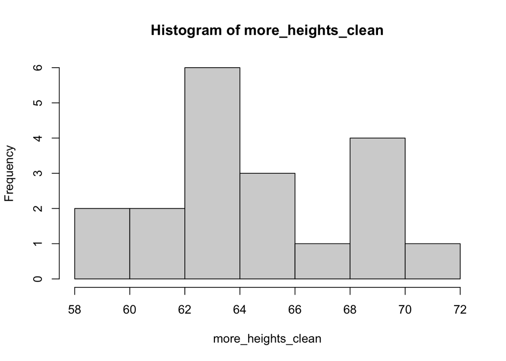

```r
# visualize data as a histogram (hint: function hist)
hist(more_heights_clean)
```

# 3 Working with data

## 3.1 Importing spreadsheet-style data into R

In the last section, we recommended organizing your work in directories (folders) according to projects. While a thorough discussion of project organization is beyond the scope of this class, we will continue to model best practices by creating a directory to hold our data:

```r
# make a directory
dir.create("data")
```

You should see the new directory appear in your project directory, in the lower right panel in RStudio. There is also a button in that panel you can use to create a new folder, but including the code to perform this task makes other people (and yourself) able to reproduce your work more easily.

Now that we have a place to store our data, we can go ahead and download the dataset:

```r
# download data from url
#download.file("https://raw.githubusercontent.com/jsfalk/acer_tutorials/master/r_intro/data/animals.csv", "data/animals.csv")
```

The code above has two arguments, both encompassed in quotation marks: first, you indicate where the data can be found online. Second, you indicate where R should store a copy of the file on your own computer.

The output from that command may look alarming, but it represents information confirming it worked. You can click on the `data` folder to ensure the file is now present.

> The option to “Import Dataset” you see after clicking on the file references some additional tools present in RStudio that can assist with various kinds of data import. Because this requires installing additional software, complete exploration of these options is outside the scop of this class. For more information, check out [this article](https://support.rstudio.com/hc/en-us/articles/218611977-Importing-Data-with-RStudio).

The data we’ve downloaded are in csv format, which stands for “comma separated values.” This means the data are organized into rows and columns, with columns separated by commas.

Now that the data are downloaded, we can import the data and assign to an object:

```r
# import data and assign to object
animals <- read.csv("data/animals.csv")
```

You should see `animals` appear in the Environment window on the upper right panel in RStudio. If you click on `animals` there, a new tab will appear next to your R script in the Source window.

> Clicking on the name of an object in the Environment window is a shortcut for running `View(animals)`; you’ll see this code appear in the Console after clicking.

Now that we have the data imported and assigned to an object, we can take some time to explore the data we’ll be using for the rest of this course. We are investigating the animal species diversity and weights found within plots at our study site. Each row holds information for a single animal, and the columns represent:

[output not shown]

The function we used to import the data is one of a family of commands used to import the data. Check out the help documentation for `read.csv` for more options for importing data.

> You can also import data directly into R using `read.csv`, using `animals <- read.csv("https://raw.githubusercontent.com/jsfalk/acer_tutorials/master/r_intro/data/animals.csv")`. For these lessons, we model downloading and importing in two steps, so you retain a copy of the data on your computer. This reflects how you’re likely to import your own data, as well as recommended practice for retaining data used in an analysis (since data online may be updated).

## 3.2 Data frames

Now that we have data imported and available, we can start to inspect the data more closely.

These data have been interpreted by R to be a data frame, which is a data structure (way of organizing data) that is analogous to tabular or spreadsheet style data. By definition, a data frame is a table made of vectors (columns) of all the same length. As we learned in our last session, a vector needs to include all of the same type of data (e.g., character, numeric). A data frame, however, can include vectors (columns) of different data types.

To learn more about this data frame, we’ll first explore its dimensions:

```r
# assess size of data frame
dim(animals)
```

```
## [1] 34786     8
```

The output reflects the number of rows first (34786), then the number of columns (8).

We can also preview the content by showing the first few rows:

```r
# preview first few rows
head(animals)
```

```
##   year  sex hindfoot_length weight   genus  species   taxa plot_type
## 1 1977    M              32     NA Neotoma albigula Rodent   Control
## 2 1977    M              31     NA Neotoma albigula Rodent   Control
## 3 1977 <NA>              NA     NA Neotoma albigula Rodent   Control
## 4 1977 <NA>              NA     NA Neotoma albigula Rodent   Control
## 5 1977 <NA>              NA     NA Neotoma albigula Rodent   Control
## 6 1977 <NA>              NA     NA Neotoma albigula Rodent   Control
```

The default number of rows shown is six. You can specify a different number using the `n =` parameter, demonstrated below using `tail`, which shows the last few rows

```r
# show last three rows
tail(animals, n = 3)
```

```
##       year  sex hindfoot_length weight       genus  species   taxa
## 34784 1998    F              20      8  Peromyscus leucopus Rodent
## 34785 1998 <NA>              NA     NA Chaetodipus      sp. Rodent
## 34786 2000 <NA>              NA     NA Chaetodipus      sp. Rodent
##              plot_type
## 34784 Rodent Exclosure
## 34785 Rodent Exclosure
## 34786 Rodent Exclosure
```

We often need to reference the names of columns, so it’s useful to print only those to the screen:

```r
# view column names
names(animals)
```

```
## [1] "year"            "sex"             "hindfoot_length" "weight"
## [5] "genus"           "species"         "taxa"            "plot_type"
```

It’s also possible to view row names using`rownames(animals)`, but our data only possess numbers for row names so it’s not very informative.

As we learned last time, we can use `str` to provide a general overview of the object:

```r
# show overview of object
str(animals)
```

```
## 'data.frame':    34786 obs. of  8 variables:
##  $ year           : int  1977 1977 1977 1977 1977 1977 1977 1978 1978 1978 ...
##  $ sex            : chr  "M" "M" NA NA ...
##  $ hindfoot_length: int  32 31 NA NA NA NA NA NA NA NA ...
##  $ weight         : int  NA NA NA NA NA NA NA NA 218 NA ...
##  $ genus          : chr  "Neotoma" "Neotoma" "Neotoma" "Neotoma" ...
##  $ species        : chr  "albigula" "albigula" "albigula" "albigula" ...
##  $ taxa           : chr  "Rodent" "Rodent" "Rodent" "Rodent" ...
##  $ plot_type      : chr  "Control" "Control" "Control" "Control" ...
```

The output provided includes:

- data structure: data frame
- dimensions: 34786 rows and 8 columns
- column-by-column information: each prefaced with a `$`, and includes the column name, data type (num, int, Factor)

> Depending on the version of R you are using, the types of variables like “sex” and “genus” may be Factor or chr. We will discuss this in greater detail in the intermediate R session.

Finally, we can also examine basic summary statistics for each column:

```r
# provide summary statistics for each column
summary(animals)
```

```
##       year          sex            hindfoot_length     weight
##  Min.   :1977   Length:34786       Min.   : 2.00   Min.   :  4.00
##  1st Qu.:1984   Class :character   1st Qu.:21.00   1st Qu.: 20.00
##  Median :1990   Mode  :character   Median :32.00   Median : 37.00
##  Mean   :1990                      Mean   :29.29   Mean   : 42.67
##  3rd Qu.:1997                      3rd Qu.:36.00   3rd Qu.: 48.00
##  Max.   :2002                      Max.   :70.00   Max.   :280.00
##                                    NA's   :3348    NA's   :2503
##     genus             species              taxa            plot_type
##  Length:34786       Length:34786       Length:34786       Length:34786
##  Class :character   Class :character   Class :character   Class :character
##  Mode  :character   Mode  :character   Mode  :character   Mode  :character
##
##
##
##
```

## 3.3 Subsetting data frames

Now that our data are available for use, we can begin extracting relevant information from them.

```r
# extract first column and assign to a variable
first_column <- animals[1]
```

As discussed last time with vectors, the square brackets (`[ ]`) are used to subset, or reference part of, a data frame. You can inspect the output object by clicking on it in the environment. It contains all of the rows for only the first column.

When a single number is included in the square brackets, R assumes you are referencing a column. When you include two numbers in square brackets separated by a comma, R assumes the **first number references the row** and the **second number references the column** you desire.

This means you can also reference the first column as follows:

```r
# extract first column
first_column_again <- animals[ , 1]
```

Leaving one field blank means you want the entire set in the output (in this case, all rows).

**Exercise:** what is the difference in results between the last two lines of code?

**Solution**

```r
# animals[1] returns a data.frame with only the first column selected
class(first_column)
```

```
## [1] "data.frame"
```

```r
# animals[ , 1] returns an integer vector with values from the first column
class(first_column_again)
```

```
## [1] "integer"
```

Similarly, we can also extract only the first row across all columns:

```r
# extract first row
first_row <- animals[1, ]
```

We can also extract slices, or sections of rows and columns, such as a single cell:

```r
# extract cell from first row of first column
single_cell <- animals[1,1]
```

To extract a range of cells, we use the same colon (`:`) syntax from last time:

```r
# extract a range of cells, rows 1 to 3, second column
range_cells <- animals[1:3, 2]
```

This works for ranges of columns as well.

We can also exclude particular parts of the dataset using a minus sign:

```r
# exclude first column
exclude_col <- animals[ , -1]
```

Combining what we know about R syntax, we can also exclude a range of cells using the `c` function:

```r
# exclude first 100 rows
exclude_range <- animals[-c(1:100), ]
```

So far, we’ve been referencing parts of the dataset based on index position, or the number of row/column. Because we have included column names in our dataset, we can also reference columns using those names:

```r
# extract column by name
name_col1 <- animals["taxa"]
name_col2 <- animals[ , "taxa"]
```

Note the example above features quotation marks around the column name. Without the quotation marks, R will assume we’re attempting to reference an object.

As we discussed with subsetting based on index above, the two objects created above differ in the data structure. `name_col1` is a data frame (with one column), while `name_col2` is a vector. Although this difference in the type of object may not matter for your analysis, it’s useful to understand that there are multiple ways to accomplish a task, each of which may make particular code work more easily.

There are additional ways to extract columns, which use R specific for complex data objects, and may be useful to recognize as your R skills progress.

The first is to use double square brackets:

```r
# double square brackets syntax
name_col3 <- animals[["taxa"]]
```

You can think of this approach as digging deeply into a complex object to retrieve data.

The final approach is equivalent to the last example, but can be considered a shortcut since it requires fewer keystrokes (no quotation marks, and only one symbol):

```r
# dollar sign syntax
name_col4 <- animals$taxa
```

Both of the last two approaches above return vectors. For more information about these different ways of accessing parts of a data frame, see [this article](https://www.r-bloggers.com/r-accessors-explained/).

## 3.4 Exporting data

Once you have performed some data manipulation, you may want to export the data for future reference or to share with collaborators. Corresponding to the `read.csv` function we used to load our data, there is a `write.csv` function to export data. The first argument is the dataframe to export, and the second argument is the path for the file that the dataframe will be stored in.

```r
# Export the data with the first hundred rows excluded
write.csv(exclude_range, "data/animals_subset.csv")
```

## 3.5 Exercises

The following exercises all use the `animals` object:

**Exercise:** code as many different ways possible to extract the column “genus”

**Solution**

```r
animals$genus
animals[5]
animals[,5]
animals[[5]]
animals["genus"]
animals[ , "genus"]
animals[["genus"]]
```

**Exercise:** extract the first 6 rows for only hindfoot length and species.

**Solution**

```r
animals[1:6, c(3, 6)]
```

```
##   hindfoot_length  species
## 1              32 albigula
## 2              31 albigula
## 3              NA albigula
## 4              NA albigula
## 5              NA albigula
## 6              NA albigula
```

**Exercise:** calculate the range and mean for weight

**Solution**

```r
range(animals$weight, na.rm = TRUE)
```

```
## [1]   4 280
```

```r
mean(animals$weight, na.rm = TRUE)
```

```
## [1] 42.67243
```

**Exercise:** Create a `data.frame` (`animals_200`) containing only the data in row 200 of the `animals` dataset.

**Solution**

```r
animals_200 <- animals[200, ]
```

**Exercise:** Notice how `nrow()` gave you the number of rows in a `data.frame`? Use that number to pull out just that last row in `animals`. Compare that with what you see as the last row using `tail()` to make sure it’s meeting expectations. Pull out that last row using nrow() instead of the row number. Create a new data frame (`animals_last`) from that last row.

**Solution**

```r
n_rows <- nrow(animals)
animals_last <- animals[n_rows, ]
```

**Exercise:** Use `nrow()` to extract the row that is in the middle of the data frame. Store the content of this row in an object named `animals_middle`.

**Solution**

```r
animals_middle <- animals[n_rows / 2, ]
```

**Exercise:** Combine `nrow()` with the `-` notation above to reproduce the behavior of `head(animals)`, keeping just the first through 6th rows of the `animals` dataset.

**Solution**

```r
animals_head <- animals[-(7:n_rows), ]
```

# 4 Data manipulation with dplyr

## 4.1 Installing and loading packages

For this section, we’ll be working with an R package called `dplyr`. A package is a group of related functions that help you accomplish particular tasks. `dplyr` is part of [`tidyverse`](https://www.tidyverse.org), which is a collection of packages that have been designed specifically to support tasks related to data science, such as data manipulation, filtering, and visualization.

The first thing we need to do is install the software:

```r
# install package
install.packages("dplyr")
```

A few notes about installing packages:

- You only need to perform this installation once per computer, or when updating R or the package.
- If you see red text output in the Console during this installation, don’t be alarmed: this doesn’t necessarily indicate a problem. You are seeing a report of the various pieces of software being downloaded and installed.
- If prompted, you should install all packages (say yes or all), as well as yes to compiling any packages
- When the installation is complete (this may take several minutes), you’ll see the command prompt (`>`) in your Console.

Once you have the software installed, you’ll need to load it:

```r
# load library/package
library(dplyr)
```

You can check to make sure the new package we’ll be using is available by executing `?select` in the Console, or by searching for that function in the help panel. You can also look in the “Packages” tab in the same panel. If the package (in this case, `dplyr`) is present in the list, it’s installed. If the box next to the package name is checked, it’s loaded. In this lesson, if you receive an error saying a function isn’t available or recognized, check to make sure the package is loaded.

## 4.2 Selecting columns and rows

First, we can explore selecting certain columns by name:

```r
# selecting columns with dplyr
sel_columns <- select(animals, sex, weight, taxa)
```

The syntax for the `select` function is to specify the dataset first, then the names of each of the columns you would like to retain in the output object. If we look at the object, we’ll see it has only three columns but all rows.

You’ll note that the column headers don’t require quotation marks; this is a shortcut programmed into `dplyr` functions.

As with base R functions, we can also select a range of columns:

```r
# select range of columns
sel_columns2 <- select(animals, sex:taxa)
```

We can also select all columns except certain ones by putting “-” in front of columns to exclude:

```r
sel_columns3 <- select(animals, -sex, -hindfoot_length)
```

In addition to these approaches, we can also use other helper functions for selecting columns: `starts_with()`, `ends_with()`, and `contains()` are examples that assist in extracting columns with headers that meet certain conditions. For example, using `starts_with(plot)` in place of the column names will give you all columns that start with the word plot

We can use a separate function to extract rows that meet particular conditions:

```r
# select rows conditionally: keep only rodents
filtered_rows <- filter(animals, taxa == "Rodent")
```

The syntax here is similar to `select`, and the conditional filters can be applied in similarly to base R functions.

**Exercise:** create a new object from animals called sex_taxa that includes only the sex and taxa columns

**Solution**

```r
sex_taxa <- select(animals, sex, taxa)
```

**Exercise:** create a new object from sex_taxa called sex_Rodent that includes only Rodent (taxa)

**Solution**

```r
sex_rodent <- filter(sex_taxa, taxa=="Rodent")
```

## 4.3 Combining commands

The last exercises used an intermediate object to obtain an object with two subsetting methods applied. It’s common in data science to apply more than one requirement for extracting data. If you want to avoid creating an intermediate object, you could nest one command inside the other:

```r
# same task as exercises, but nested commands
sex_Rodent <- select(filter(animals, taxa == "Rodent"), sex, taxa)
```

In this case, `filter(animals, taxa == "Rodent")` becomes the input for `select`.

While this is a common approach, especially in base R, it can be difficult for us as coders to read and interpret the code.

One of the most useful features of `dplyr` is its inclusion of a programming method called pipes. This approach can be found in many programming languages, in part because of its utility: a pipe sends the output from the lefthand side of the symbol as the input for the righthand side. In R, pipes are represented as `%>%`.

We can use pipes to connect the same two data extraction tasks:

```r
# same task as above, but with pipes
piped <- animals %>%
  select(sex, taxa) %>%
  filter(taxa == "Rodent")
```

The command above starts by naming the object that will result from this assignment. The dataset is named as the first input. Because executing the name of an object sends the object contents as output, this means the second line receives the object as input. The output from the `select` line is sent as input to the `filter` line. This effectively demonstrates how pipes can be used to connect multiple commands together.

> Now that we are running code in chunks that span multiple lines, you can see one of the other nice features of RStudio: your cursor can be placed on any line of the multi-line chunk when you execute, and the entire set of code will run together.

These examples also help highlight the importance of style and convention in code formatting. After the first line, the code is indented. While this isn’t necessary for the code to work, it does make it a lot easier to read and understand the code.

Let’s take a look at another example of piped commands:

```r
# extract sex and weight from samples before 1995
piped2 <- animals %>%
  filter(year < 1995) %>%
  select(sex, weight)
```

In the code above, we’re applying a mathematical condition to find specific rows, and the selecting certain columns. Does the order of commands differ? We can switch the order of the `filter` and `select` lines to see:

```r
piped3 <- clinical %>%
  select(sex, weight) %>%
  filter(year < 1995)
```

**Exercise:** Using pipes, subset the `animals` data to include animals under 5 grams collected before 1995, and retain only the columns `year`, `sex`, and `weight`.

**Solution**

```r
animals %>%
  filter(weight < 5) %>%
  filter(year < 1995) %>%
  select(year, sex, weight)
```

```
##    year  sex weight
## 1  1981    F      4
## 2  1982    F      4
## 3  1985    F      4
## 4  1985    M      4
## 5  1981 <NA>      4
## 6  1983    M      4
## 7  1985    M      4
## 8  1985    M      4
## 9  1977    M      4
## 10 1982    F      4
## 11 1985    M      4
## 12 1985    M      4
## 13 1985    F      4
## 14 1985    M      4
## 15 1985    M      4
```

## 4.4 Mutate

This lesson so far has mostly shown new ways of accomplishing the same tasks we learned in the last lesson. `dplyr` includes much more functionality, however, including the ability to `mutate` columns. Common tasks for which `mutate` is useful include unit conversions, transformation, and creating ratios from among existing columns.

We can use this function to convert the `weight` column to kilograms:

```r
# convert grams to kilograms
clinical_kg <- animals %>%
  mutate(weight_kg = weight / 1000)
```

The actual conversion works by providing a formula (`weight / 1000`) and the name of the new column (`weight_kg`). If you inspect the resulting object, you’ll see `weight_kg` added as a new column at the end of the table.

> `mutate` works by retaining all previous columns and creating new columns as per the formula specified. `dplyr` also includes `transmute`, which drops the existing columns used to calculcate the new columns.

We can use `mutate` to perform multiple conversions at once:

```r
# convert weight to kgs and lbs at same time, and we don't always need to assign to object
animals %>%
  mutate(weight_kg = weight / 1000,
         weight_lb = weight_kg * 2.2) %>%
  glimpse() # preview data output
```

```
## Rows: 34,786
## Columns: 10
## $ year            <int> 1977, 1977, 1977, 1977, 1977, 1977, 1977, 1978, 1978,…
## $ sex             <chr> "M", "M", NA, NA, NA, NA, NA, NA, "M", NA, NA, "M", "…
## $ hindfoot_length <int> 32, 31, NA, NA, NA, NA, NA, NA, NA, NA, NA, 32, NA, 3…
## $ weight          <int> NA, NA, NA, NA, NA, NA, NA, NA, 218, NA, NA, 204, 200…
## $ genus           <chr> "Neotoma", "Neotoma", "Neotoma", "Neotoma", "Neotoma"…
## $ species         <chr> "albigula", "albigula", "albigula", "albigula", "albi…
## $ taxa            <chr> "Rodent", "Rodent", "Rodent", "Rodent", "Rodent", "Ro…
## $ plot_type       <chr> "Control", "Control", "Control", "Control", "Control"…
## $ weight_kg       <dbl> NA, NA, NA, NA, NA, NA, NA, NA, 0.218, NA, NA, 0.204,…
## $ weight_lb       <dbl> NA, NA, NA, NA, NA, NA, NA, NA, 0.4796, NA, NA, 0.448…
```

The code above also features a new function, `glimpse`, that can be useful when developing new piped code. Note that we did not assign the output above to a new object; we allowed it to be printed to the Console. Because this is a large dataset, that type of output can be unweildy. `glimpse` allows us to see a preview of the data, including the two new columns created.

**Exercise:** Create a new data frame from the surveys data that meets the following criteria: contains only the `species` column and a new column called `hindfoot_cm` containing the `hindfoot_length` values converted to centimeters. In this `hindfoot_cm` column, there are no NAs and all values are less than 3.

**Solution**

```r
surveys_hindfoot_cm <- animals %>%
    filter(!is.na(hindfoot_length)) %>%
    mutate(hindfoot_cm = hindfoot_length / 10) %>%
    filter(hindfoot_cm < 3) %>%
    select(species, hindfoot_cm)
```

## 4.5 Split-apply-combine

Our `animals` dataset includes categorical (character) data. One example is the `sex` column. We can assess the different categories available using a base R function:

```r
# show categories in gender
unique(animals$sex)
```

```
## [1] "M" NA  "F"
```

`dplyr` includes an approach called split-apply-combine that allows us to:

- split data into groups,
- apply a task for each group,
- combine the results back together into a single table.

We can try out this approach by counting the number of each gender in our dataset:

```r
# count number of individuals of each gender
animals %>%
  group_by(sex) %>%
  tally()
```

```
## # A tibble: 3 x 2
##   sex       n
##   <chr> <int>
## 1 F     15690
## 2 M     17348
## 3 <NA>   1748
```

`group_by` is not particularly useful by itself, but powerful together with a second function like `tally`. The two columns in the resulting tibble represent the categories from `group_by` and the number of cases for each gender (n).

An additional function for use with `group_by` is `summarize`:

```r
# summarize average days to death by gender
animals %>%
  group_by(sex) %>%
  summarize(mean_weight = mean(weight, na.rm = TRUE))
```

```
## # A tibble: 3 x 2
##   sex   mean_weight
##   <chr>       <dbl>
## 1 F            42.2
## 2 M            43.0
## 3 <NA>         64.7
```

Similar to `mutate`, we provide `summarize` with a formula indicating how we would like the groups to be handled.

We can apply an additional filter to remove this missing data, prior to grouping:

```r
# remove NA
animals %>%
  filter(!is.na(sex)) %>%
  group_by(sex) %>%
  summarize(mean_weight = mean(weight, na.rm=TRUE))
```

```
## # A tibble: 2 x 2
##   sex   mean_weight
##   <chr>       <dbl>
## 1 F            42.2
## 2 M            43.0
```

**Exercise:** Create a data frame called `measurements_complete` from `animals` that contains no missing data for weight or hindfoot length.

**Solution**

```r
# option 1: using two filters
measurements_complete <- animals %>%
  filter(!is.na(weight)) %>%
  filter(!is.na(hindfoot_length))

# option 2: using one filter with a boolean operator
measurements_complete <- animals %>%
  filter(!is.na(weight) & !is.na(hindfoot_length))
```

**Exercise:** How many animals were caught in each plot_type surveyed?

**Solution**

```r
animals %>%
  count(plot_type)
```

```
##                   plot_type     n
## 1                   Control 15611
## 2  Long-term Krat Exclosure  5118
## 3          Rodent Exclosure  4233
## 4 Short-term Krat Exclosure  5906
## 5         Spectab exclosure  3918
```

**Exercise:** Use `group_by()` and `summarize()` to find the mean, min, and max hindfoot length for each species. Also add the number of observations (hint: see `?n`).

**Solution**

```r
animals %>%
  filter(!is.na(hindfoot_length)) %>%
  group_by(species) %>%
  summarize(
    mean_hindfoot_length = mean(hindfoot_length),
    min_hindfoot_length = min(hindfoot_length),
    max_hindfoot_length = max(hindfoot_length),
    n = n()
  )
```

```
## # A tibble: 22 x 5
##    species     mean_hindfoot_length min_hindfoot_length max_hindfoot_leng…     n
##    <chr>                      <dbl>               <int>              <int> <int>
##  1 albigula                    32.3                  21                 70  1074
##  2 baileyi                     26.1                   2                 47  2864
##  3 eremicus                    20.2                  11                 30  1212
##  4 flavus                      15.6                   7                 38  1493
##  5 fulvescens                  17.5                  15                 20    73
##  6 fulviventer                 26.7                  21                 38    41
##  7 harrisi                     33                    31                 35     2
##  8 hispidus                    28.0                  20                 39   162
##  9 intermedius                 22.2                  20                 23     9
## 10 leucogaster                 20.5                  12                 39   920
## # … with 12 more rows
```

**Exercise:** What was the heaviest animal measured in each year? Return the columns `year`, `genus`, `species`, and `weight`.

**Solution**

```r
animals %>%
  filter(!is.na(weight)) %>%
  group_by(year) %>%
  filter(weight == max(weight)) %>%
  select(year, genus, species, weight) %>%
  arrange(year)
```

```
## # A tibble: 27 x 4
## # Groups:   year [26]
##     year genus     species     weight
##    <int> <chr>     <chr>        <int>
##  1  1977 Dipodomys spectabilis    149
##  2  1978 Neotoma   albigula       232
##  3  1978 Neotoma   albigula       232
##  4  1979 Neotoma   albigula       274
##  5  1980 Neotoma   albigula       243
##  6  1981 Neotoma   albigula       264
##  7  1982 Neotoma   albigula       252
##  8  1983 Neotoma   albigula       256
##  9  1984 Neotoma   albigula       259
## 10  1985 Neotoma   albigula       225
## # … with 17 more rows
```

## 4.6 Filtering data based on number of cases of each type

We’re going to perform one last manipulation on this second dataset for next time, which will allow us to reduce the total number of species present in this dataset.

First, we’ll need to count how many examples of each species exist in the dataset:

```r
# counting number of records for each species
species_counts <- animals %>%
  count(species) %>%
  arrange(n)
```

The `count` function is similar to `tally`, but doesn’t need to have `group_by` applied first. The `arrange` function added at the end sorts the table using the column specified. Although this isn’t necessary for the analysis to proceed, it makes it easier for us to interpret the results.

Next, we’ll identify which species are represented by at least 500 examples in this dataset:

```r
# get names of frequently occurring species
frequent_species <- species_counts %>%
  filter(n >= 500)
```

We can then use this object to filter based on the number of examples:

```r
# extract data from species to keep
animals_reduced <- animals %>%
  filter(species %in% frequent_species$species)
```

The new syntax here is `%in%`, which allows you to compare each entry in `species` from `animals` to the species column in `frequent_species` (remember that `frequent_species$species` means the `species` column from `frequent_species`). This keeps only cases from the `animals` dataset that are from species for which we have many examples.

Finally, we’ll write the final output to a file:

```r
# save results to file in data/ named animals_reduced
write.csv(animals_reduced, "data/animals_reduced.csv")
```

**Exercise:** extract all species with more than 200 examples

**Solution**

```r
animals %>%
  count(species) %>%
  filter(n > 200)
```

```
##         species     n
## 1      albigula  1252
## 2       baileyi  2891
## 3     bilineata   303
## 4      eremicus  1299
## 5        flavus  1597
## 6       harrisi   437
## 7   leucogaster  1006
## 8   maniculatus   899
## 9     megalotis  2609
## 10     merriami 10596
## 11        ordii  3027
## 12 penicillatus  3123
## 13  spectabilis  2504
## 14    spilosoma   248
## 15     torridus  2249
```

If you’d like more information on these functions and others available (including methods of joining multiple tables together), please check out the [`dplyr` cheatsheet](https://github.com/rstudio/cheatsheets/raw/master/data-transformation.pdf).

# 5 Wrapping up

## 5.1 Closing RStudio

**When you are done working in RStudio,** you should save any changes to your R script. When you close RStudio, you will see a pop-up box asking if you want to save your workspace image. We do not recommend saving your project in this way, as it creates extra (hidden) files on your computer that can be unweildy in size and inadvertently retain sensitive data (if you’re working with PHI or other private data). If you’ve saved your R script, you can recreate all the work you’ve accomplished. For more information on this topic, please review [this explanation](https://www.stat.ubc.ca/~jenny/STAT545A/block01_basicsWorkspaceWorkingDirProject.html#workspace-.rdata). If you would like to prevent this box from popping up in the future, we recommend:

- Go to `Tools -> Global Options` (Global means for all projects; you can also change this for each project using `Project Options`)
- In the drop-down menu next to `Save workspace to ~/.Rdata on exit` select `Never`.